# Carlos Michel Mourra Díaz

## Random Forest Classifier

```python
from sklearn.ensemble import RandomForestClassifier
# prediccion por medio del modelo Random Forest Classifier
clf = RandomForestClassifier(n_estimators=10)
clf = clf.fit(X_train, y_train)
y_predict = clf.predict(X_test)
y_predict
```

```
array([1, 0, 0, ..., 1, 1, 1])
```

```python
# Imprimir las medidas que indiquen que tan bien predijo el modelo los datos
print("Accuracy: {}".format(accuracy_score(y_test, y_predict)))
print("Precision: {}".format(precision_score(y_test, y_predict, average="macro")))
print("Recall: {}".format(recall_score(y_test, y_predict, average="macro")))
print("F-score: {}".format(f1_score(y_test, y_predict, average="macro")))
```

```
Accuracy: 1.0
Precision: 1.0
Recall: 1.0
F-score: 1.0
```

```python
# Resumen de las medidas para cada clasificacion
target_names = ["Edible","Poisonous"]
print(classification_report(y_test, y_predict, target_names=target_names))
```

```
              precision    recall  f1-score   support

      Edible       1.00      1.00      1.00      1272
   Poisonous       1.00      1.00      1.00      1166

    accuracy                           1.00      2438
   macro avg       1.00      1.00      1.00      2438
weighted avg       1.00      1.00      1.00      2438
```

```
[[1272    0]
 [   0 1166]]
```

```
<sklearn.metrics._plot.confusion_matrix.ConfusionMatrixDisplay at 0x7f8ea9207f70>
```

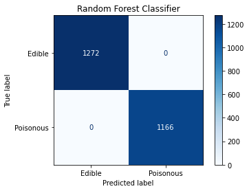

```python
# Matriz de confusion para comestibles y venenosos
print(confusion_matrix(y_test, y_predict))
rfc = plot_confusion_matrix(clf, X_test, y_test, cmap=plt.cm.Blues,
                      display_labels=["Edible","Poisonous"])
rfc.ax_.set_title("Random Forest Classifier")
rfc
```

Podemos ver que el modelo de random forest con 10 arboles fue efectivo y pudo predecir correctamente la clase de todos los elementos.

## Stochastic Gradient Descent

```python
from sklearn.linear_model import SGDClassifier
# prediccion por medio del modelo Stochastic Gradient Descent
clf2 = SGDClassifier(loss="hinge", penalty="l2", max_iter=5)
clf2 = clf2.fit(X_train, y_train)
y_predict = clf2.predict(X_test)
y_predict
```

```
array([0, 0, 0, ..., 1, 1, 1])
```

```python
# Imprimir las medidas que indiquen que tan bien predijo el modelo los datos
print("Accuracy: {}".format(accuracy_score(y_test, y_predict)))
print("Precision: {}".format(precision_score(y_test, y_predict, average="macro")))
print("Recall: {}".format(recall_score(y_test, y_predict, average="macro")))
print("F-score: {}".format(f1_score(y_test, y_predict, average="macro")))
```

```
Accuracy: 0.8666940114848236
Precision: 0.8843490745850323
Recall: 0.8620640365923384
F-score: 0.8638724278400169
```

```python
# Resumen de las medidas para cada clasificacion
target_names = ["Edible","Poisonous"]
print(classification_report(y_test, y_predict, target_names=target_names))
```

```
              precision    recall  f1-score   support

      Edible       0.81      0.97      0.88      1272
   Poisonous       0.96      0.76      0.84      1166

    accuracy                           0.87      2438
   macro avg       0.88      0.86      0.86      2438
weighted avg       0.88      0.87      0.86      2438
```

```
[[1232   40]
 [ 285  881]]
```

```
<sklearn.metrics._plot.confusion_matrix.ConfusionMatrixDisplay at 0x7f8ea7753f10>
```

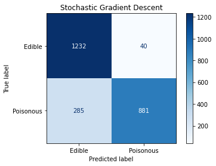

```python
# Matriz de confusion para comestibles y venenosos
print(confusion_matrix(y_test, y_predict))
sgd = plot_confusion_matrix(clf2, X_test, y_test, cmap=plt.cm.Blues,
                      display_labels=["Edible","Poisonous"])

sgd.ax_.set_title("Stochastic Gradient Descent")
sgd
```

## Decision Trees

```python
from sklearn import tree
# prediccion por medio del modelo Decision Trees
clf_tree = tree.DecisionTreeClassifier()
clf_tree = clf_tree.fit(X_train, y_train)
y_predict = clf_tree.predict(X_test)
y_predict
```

```
array([1, 0, 0, ..., 1, 1, 1])
```

```python
# Imprimir las medidas que indiquen que tan bien predijo el modelo los datos
print("Accuracy: {}".format(accuracy_score(y_test, y_predict)))
print("Precision: {}".format(precision_score(y_test, y_predict, average="macro")))
print("Recall: {}".format(recall_score(y_test, y_predict, average="macro")))
print("F-score: {}".format(f1_score(y_test, y_predict, average="macro")))
```

```
Accuracy: 1.0
Precision: 1.0
Recall: 1.0
F-score: 1.0
```

```python
# Resumen de las medidas para cada clasificacion
target_names = ["Edible","Poisonous"]
print(classification_report(y_test, y_predict, target_names=target_names))
```

```
              precision    recall  f1-score   support

      Edible       1.00      1.00      1.00      1272
   Poisonous       1.00      1.00      1.00      1166

    accuracy                           1.00      2438
   macro avg       1.00      1.00      1.00      2438
weighted avg       1.00      1.00      1.00      2438
```

```
[[1272    0]
 [   0 1166]]
```

```
<sklearn.metrics._plot.confusion_matrix.ConfusionMatrixDisplay at 0x7f8e8d7c69a0>
```

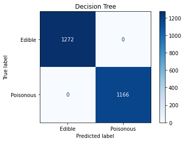

```python
# Matriz de confusion para comestibles y venenosos
print(confusion_matrix(y_test, y_predict))
dt = plot_confusion_matrix(clf_tree, X_test, y_test, cmap=plt.cm.Blues,
                      display_labels=["Edible","Poisonous"])
dt.ax_.set_title("Decision Tree")
dt
```

Es posible observar que el modelo de arboles de decision fue capaz de predecir correctamente las clases de todos los elementos.

# One Hot Encoding

Aunque la codificación de etiquetas es directa, tiene la desventaja de que los algoritmos pueden malinterpretar los valores numéricos como si tuvieran algún tipo de jerarquía / orden en ellos. Este problema de ordenación se aborda en otro enfoque alternativo común llamado "Codificación One-Hot". En esta estrategia, cada valor de categoría se convierte en una nueva columna y se le asigna un valor de 1 o 0 (notación para verdadero / falso) a la columna.

[figure not shown]

## Recolección de datos

```python
data_one = pd.read_csv('../Downloads/mushrooms.csv')

data_one = pd.get_dummies(data_one, drop_first=True)

X_one = data_one.drop(columns=['class_p'])
y_one = data_one['class_p']

X_trainOne, X_testOne, y_trainOne, y_testOne = train_test_split(X_one, y_one, test_size=0.3, random_state=0)

data_one
```

|  | class_p | cap-shape_c | cap-shape_f | cap-shape_k | cap-shape_s | cap-shape_x | cap-surface_g | cap-surface_s | cap-surface_y | cap-color_c | ... | population_n | population_s | population_v | population_y | habitat_g | habitat_l | habitat_m | habitat_p | habitat_u | habitat_w |
| --- | --- | --- | --- | --- | --- | --- | --- | --- | --- | --- | --- | --- | --- | --- | --- | --- | --- | --- | --- | --- | --- |
| 0 | 1 | 0 | 0 | 0 | 0 | 1 | 0 | 1 | 0 | 0 | ... | 0 | 1 | 0 | 0 | 0 | 0 | 0 | 0 | 1 | 0 |
| 1 | 0 | 0 | 0 | 0 | 0 | 1 | 0 | 1 | 0 | 0 | ... | 1 | 0 | 0 | 0 | 1 | 0 | 0 | 0 | 0 | 0 |
| 2 | 0 | 0 | 0 | 0 | 0 | 0 | 0 | 1 | 0 | 0 | ... | 1 | 0 | 0 | 0 | 0 | 0 | 1 | 0 | 0 | 0 |
| 3 | 1 | 0 | 0 | 0 | 0 | 1 | 0 | 0 | 1 | 0 | ... | 0 | 1 | 0 | 0 | 0 | 0 | 0 | 0 | 1 | 0 |
| 4 | 0 | 0 | 0 | 0 | 0 | 1 | 0 | 1 | 0 | 0 | ... | 0 | 0 | 0 | 0 | 1 | 0 | 0 | 0 | 0 | 0 |
| ... | ... | ... | ... | ... | ... | ... | ... | ... | ... | ... | ... | ... | ... | ... | ... | ... | ... | ... | ... | ... | ... |
| 8119 | 0 | 0 | 0 | 1 | 0 | 0 | 0 | 1 | 0 | 0 | ... | 0 | 0 | 0 | 0 | 0 | 1 | 0 | 0 | 0 | 0 |
| 8120 | 0 | 0 | 0 | 0 | 0 | 1 | 0 | 1 | 0 | 0 | ... | 0 | 0 | 1 | 0 | 0 | 1 | 0 | 0 | 0 | 0 |
| 8121 | 0 | 0 | 1 | 0 | 0 | 0 | 0 | 1 | 0 | 0 | ... | 0 | 0 | 0 | 0 | 0 | 1 | 0 | 0 | 0 | 0 |
| 8122 | 1 | 0 | 0 | 1 | 0 | 0 | 0 | 0 | 1 | 0 | ... | 0 | 0 | 1 | 0 | 0 | 1 | 0 | 0 | 0 | 0 |
| 8123 | 0 | 0 | 0 | 0 | 0 | 1 | 0 | 1 | 0 | 0 | ... | 0 | 0 | 0 | 0 | 0 | 1 | 0 | 0 | 0 | 0 |

8124 rows × 96 columns

## K-Nearest Neighbor

```python
# Clasificación K Nearest neighbors
k = 5
# Definición del clasificador
classifier = KNeighborsClassifier(n_neighbors=k)
# Entrenamiento del clasificador con lo datos de entrenamiento y valores de clase para cada ejemplo
classifier.fit(X_trainOne, y_trainOne)
# Predicción con el clasificador entrenado en los datos de evaluación
y_predict = classifier.predict(X_testOne)
y_predict

# Clasificación K Nearest neighbors
k2 = 41
# Definición del clasificador
classifier2 = KNeighborsClassifier(n_neighbors=k2)
# Entrenamiento del clasificador con lo datos de entrenamiento y valores de clase para cada ejemplo
classifier2.fit(X_trainOne, y_trainOne)
# Predicción con el clasificador entrenado en los datos de evaluación
y_predict2 = classifier2.predict(X_testOne)
y_predict2
```

```
array([1, 0, 0, ..., 1, 1, 1], dtype=uint8)
```

```python
# Imprimir las medidas que indiquen que tan bien predijo el modelo los datos
print("Accuracy: {}".format(accuracy_score(y_testOne, y_predict)))
print("Precision: {}".format(precision_score(y_testOne, y_predict, average="macro")))
print("Recall: {}".format(recall_score(y_testOne, y_predict, average="macro")))
print("F-score: {}".format(f1_score(y_testOne, y_predict, average="macro")))
```

```
Accuracy: 1.0
Precision: 1.0
Recall: 1.0
F-score: 1.0
```

```python
# Resumen de las medidas para cada clasificacion
target_names = ["Edible","Poisonous"]
print(classification_report(y_testOne, y_predict, target_names=target_names))
```

```
              precision    recall  f1-score   support

      Edible       1.00      1.00      1.00      1272
   Poisonous       1.00      1.00      1.00      1166

    accuracy                           1.00      2438
   macro avg       1.00      1.00      1.00      2438
weighted avg       1.00      1.00      1.00      2438
```

```
[[1272    0]
 [   0 1166]]
```

```
<sklearn.metrics._plot.confusion_matrix.ConfusionMatrixDisplay at 0x7f8e8f920910>
```

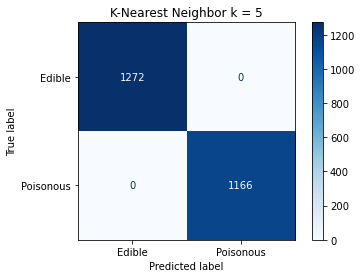

```python
# Matriz de confusion para comestibles y venenosos
print(confusion_matrix(y_testOne, y_predict))
knn = plot_confusion_matrix(classifier, X_testOne, y_testOne, cmap=plt.cm.Blues,
                      display_labels=["Edible","Poisonous"])
knn.ax_.set_title("K-Nearest Neighbor k = 5")
knn
```

```
[[1272    0]
 [   2 1164]]
```

```
<sklearn.metrics._plot.confusion_matrix.ConfusionMatrixDisplay at 0x7f8e8f920e50>
```

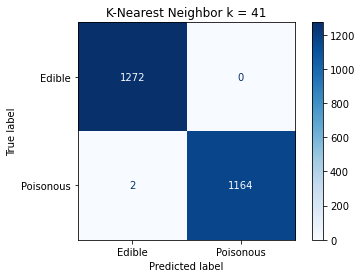

```python
# Matriz de confusion para comestibles y venenosos
print(confusion_matrix(y_testOne, y_predict2))
knn2 = plot_confusion_matrix(classifier2, X_testOne, y_testOne, cmap=plt.cm.Blues,
                      display_labels=["Edible","Poisonous"])
knn2.ax_.set_title("K-Nearest Neighbor k = 41")
knn2
```

Como podemos ver el resultado el modelo KNN con un valor de k = 5 predijo correctamente las clases para todos los elementos, sin embargo, tras probar con otros valores de k como lo son 31,41,51 y fue posible observar que presentaba una tasa de error muy pequeña menor al 1%, por lo que podriamos pensar que el asignar los datos por medio de 1 y 0 genera una mayor robustez en el modelo.

## Support Vector Matrix

```python
# Clasificación SVM
# Definición del clasificador
svm_classifier = SVC(kernel="linear", probability=True)
# Entrenamiento del clasificador con lo datos de entrenamiento y valores de clase para cada ejemplo
svm_classifier.fit(X_trainOne, y_trainOne)
# Predicción con el clasificador entrenado en los datos de evaluación
y_predict = svm_classifier.predict(X_testOne)
y_predict
```

```
array([1, 0, 0, ..., 1, 1, 1], dtype=uint8)
```

```python
# Imprimir las medidas que indiquen que tan bien predijo el modelo los datos
print("Accuracy: {}".format(accuracy_score(y_testOne, y_predict)))
print("Precision: {}".format(precision_score(y_testOne, y_predict, average="macro")))
print("Recall: {}".format(recall_score(y_testOne, y_predict, average="macro")))
print("F-score: {}".format(f1_score(y_testOne, y_predict, average="macro")))
```

```
Accuracy: 1.0
Precision: 1.0
Recall: 1.0
F-score: 1.0
```

```python
# Resumen de las medidas para cada clasificacion
target_names = ["Edible","Poisonous"]
print(classification_report(y_testOne, y_predict, target_names=target_names))
```

```
              precision    recall  f1-score   support

      Edible       1.00      1.00      1.00      1272
   Poisonous       1.00      1.00      1.00      1166

    accuracy                           1.00      2438
   macro avg       1.00      1.00      1.00      2438
weighted avg       1.00      1.00      1.00      2438
```

```
[[1272    0]
 [   0 1166]]
```

```
<sklearn.metrics._plot.confusion_matrix.ConfusionMatrixDisplay at 0x7f8ea73f73a0>
```

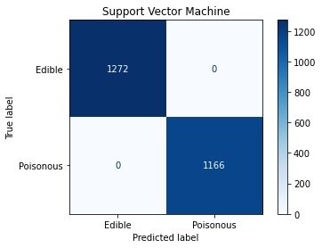

```python
# Matriz de confusion para comestibles y venenosos
print(confusion_matrix(y_testOne, y_predict))
svm = plot_confusion_matrix(svm_classifier, X_testOne, y_testOne, cmap=plt.cm.Blues,
                      display_labels=["Edible","Poisonous"])
svm.ax_.set_title("Support Vector Machine")
svm
```

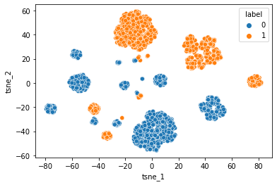

```python
# podemos ver como se encuentran distribuidos los elementos de nuestro set de datos
X_test_embedded = TSNE(n_components=2).fit_transform(X_testOne)
plt.figure()
tsne_result_df = pd.DataFrame({'tsne_1': X_test_embedded[:,0], 'tsne_2': X_test_embedded[:,1], 'label': y_test})
sns.scatterplot(x='tsne_1', y='tsne_2', hue='label', data=tsne_result_df)
```

En este caso podemos observar que para los datos modificados por hot one encoding presenta mejores resultados pra el modelo de svm, en donde se logro predecir correctamente la clase de todos los elementos. Al observar por medio de un scatter plot podemos observar que los elementos se distribuyen mejor en sus regiones correspondientes.

## Random Forest Classifier

```python
from sklearn.ensemble import RandomForestClassifier
# prediccion por medio del modelo Random Forest Classifier
clf = RandomForestClassifier(n_estimators=10)
clf = clf.fit(X_trainOne, y_train)
y_predict = clf.predict(X_testOne)
y_predict
```

```
array([1, 0, 0, ..., 1, 1, 1])
```

```python
# Imprimir las medidas que indiquen que tan bien predijo el modelo los datos
print("Accuracy: {}".format(accuracy_score(y_testOne, y_predict)))
print("Precision: {}".format(precision_score(y_testOne, y_predict, average="macro")))
print("Recall: {}".format(recall_score(y_testOne, y_predict, average="macro")))
print("F-score: {}".format(f1_score(y_testOne, y_predict, average="macro")))
```

```
Accuracy: 1.0
Precision: 1.0
Recall: 1.0
F-score: 1.0
```

```python
# Resumen de las medidas para cada clasificacion
target_names = ["Edible","Poisonous"]
print(classification_report(y_testOne, y_predict, target_names=target_names))
```

```
              precision    recall  f1-score   support

      Edible       1.00      1.00      1.00      1272
   Poisonous       1.00      1.00      1.00      1166

    accuracy                           1.00      2438
   macro avg       1.00      1.00      1.00      2438
weighted avg       1.00      1.00      1.00      2438
```

```
[[1272    0]
 [   0 1166]]
```

```
<sklearn.metrics._plot.confusion_matrix.ConfusionMatrixDisplay at 0x7f8ea6eb5e80>
```

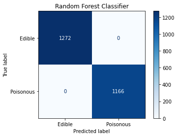

```python
# Matriz de confusion para comestibles y venenosos
print(confusion_matrix(y_testOne, y_predict))
rfc = plot_confusion_matrix(clf, X_testOne, y_testOne, cmap=plt.cm.Blues,
                      display_labels=["Edible","Poisonous"])
rfc.ax_.set_title("Random Forest Classifier")
rfc
```

Podemos ver que el modelo de Random Forest Classifier para los valores binarios asignados fue capaz de predecir todas las clases correctamente utilizando 10 arboles.

## Stochastic Gradient Descent

```python
from sklearn.linear_model import SGDClassifier
# prediccion por medio del modelo Stochastic Gradient Descent
clf2 = SGDClassifier(loss="hinge", penalty="l2", max_iter=5)
clf2 = clf2.fit(X_trainOne, y_trainOne)
y_predict = clf2.predict(X_testOne)
y_predict
```

```
array([1, 0, 0, ..., 1, 1, 1], dtype=uint8)
```

```python
# Imprimir las medidas que indiquen que tan bien predijo el modelo los datos
print("Accuracy: {}".format(accuracy_score(y_testOne, y_predict)))
print("Precision: {}".format(precision_score(y_testOne, y_predict, average="macro")))
print("Recall: {}".format(recall_score(y_testOne, y_predict, average="macro")))
print("F-score: {}".format(f1_score(y_testOne, y_predict, average="macro")))
```

```
Accuracy: 1.0
Precision: 1.0
Recall: 1.0
F-score: 1.0
```

```python
# Resumen de las medidas para cada clasificacion
target_names = ["Edible","Poisonous"]
print(classification_report(y_testOne, y_predict, target_names=target_names))
```

```
              precision    recall  f1-score   support

      Edible       1.00      1.00      1.00      1272
   Poisonous       1.00      1.00      1.00      1166

    accuracy                           1.00      2438
   macro avg       1.00      1.00      1.00      2438
weighted avg       1.00      1.00      1.00      2438
```

```
[[1272    0]
 [   0 1166]]
```

```
<sklearn.metrics._plot.confusion_matrix.ConfusionMatrixDisplay at 0x7f8e8e623dc0>
```

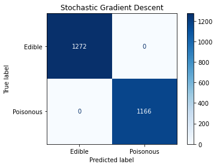

```python
# Matriz de confusion para comestibles y venenosos
print(confusion_matrix(y_testOne, y_predict))
sgd = plot_confusion_matrix(clf2, X_testOne, y_testOne, cmap=plt.cm.Blues,
                      display_labels=["Edible","Poisonous"])

sgd.ax_.set_title("Stochastic Gradient Descent")
sgd
```

El modelo de descenso de gradiente en esta numeracion binaria fue capaz de predecir la clase de todos los elementos, posblemente esto se deba a que este tipo de clasificación provoca menos ruido en una funcion matematica, que los pesos que se toman debido a los valores numericos que se dan en el label encoding.

## Decision Trees

```python
from sklearn import tree
# prediccion por medio del modelo Decision Trees
clf_tree = tree.DecisionTreeClassifier()
clf_tree = clf_tree.fit(X_trainOne, y_trainOne)
y_predict = clf_tree.predict(X_testOne)
y_predict
```

```
array([1, 0, 0, ..., 1, 1, 1], dtype=uint8)
```

```python
# Imprimir las medidas que indiquen que tan bien predijo el modelo los datos
print("Accuracy: {}".format(accuracy_score(y_testOne, y_predict)))
print("Precision: {}".format(precision_score(y_testOne, y_predict, average="macro")))
print("Recall: {}".format(recall_score(y_testOne, y_predict, average="macro")))
print("F-score: {}".format(f1_score(y_testOne, y_predict, average="macro")))
```

```
Accuracy: 1.0
Precision: 1.0
Recall: 1.0
F-score: 1.0
```

```python
# Resumen de las medidas para cada clasificacion
target_names = ["Edible","Poisonous"]
print(classification_report(y_testOne, y_predict, target_names=target_names))
```

```
              precision    recall  f1-score   support

      Edible       1.00      1.00      1.00      1272
   Poisonous       1.00      1.00      1.00      1166

    accuracy                           1.00      2438
   macro avg       1.00      1.00      1.00      2438
weighted avg       1.00      1.00      1.00      2438
```

```
[[1272    0]
 [   0 1166]]
```

```
<sklearn.metrics._plot.confusion_matrix.ConfusionMatrixDisplay at 0x7f8e8d9ee3a0>
```

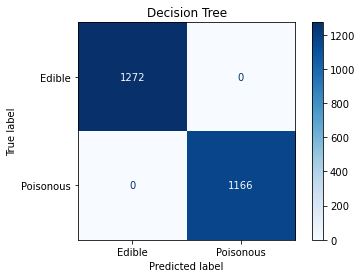

```python
# Matriz de confusion para comestibles y venenosos
print(confusion_matrix(y_testOne, y_predict))
dt = plot_confusion_matrix(clf_tree, X_testOne, y_testOne, cmap=plt.cm.Blues,
                      display_labels=["Edible","Poisonous"])
dt.ax_.set_title("Decision Tree")
dt
```

El modelo de Arboles de decisión tambien fue capaz de predecir correctamente las clases de todos los elementos.

## Conclusiones

Tras los analisis realizados con los algoritmos de clasificación:

- K Nearest Neighbor
- Support Vector Machine
- Random Forest Classifier
- Stochastic Gradient Descent
- Decision Trees

- Label Encoding
- One Hot Encoding

# Información Adicional del archivo de Hongos

## Comestibles y Venenosos

```python
Fung['class'].value_counts().to_frame()
```

|  | class |
| --- | --- |
| e | 4208 |
| p | 3916 |

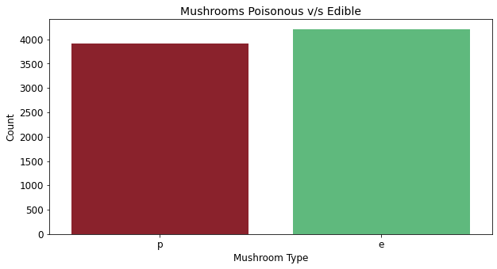

```python
plt.figure(figsize=(10,5))
plt.title('Mushrooms Poisonous v/s Edible', fontsize=14)
sns.countplot(x="class", data=Fung, palette=('#9b111e','#50c878'))
plt.xlabel("Mushroom Type", fontsize=12)
plt.ylabel("Count", fontsize=12)
plt.xticks(fontsize=12)
plt.yticks(fontsize=12)
plt.show()
```

## Color de los hongos

```python
Fung.groupby(['cap-color'])['class'].value_counts().to_frame()
```

| cap-color | class | class |
| --- | --- | --- |
| b | p | 120 |
|  | e | 48 |
| c | e | 32 |
|  | p | 12 |
| e | p | 876 |
|  | e | 624 |
| g | e | 1032 |
|  | p | 808 |
| n | e | 1264 |
|  | p | 1020 |
| p | p | 88 |
|  | e | 56 |
| r | e | 16 |
| u | e | 16 |
| w | e | 720 |
|  | p | 320 |
| y | p | 672 |
|  | e | 400 |

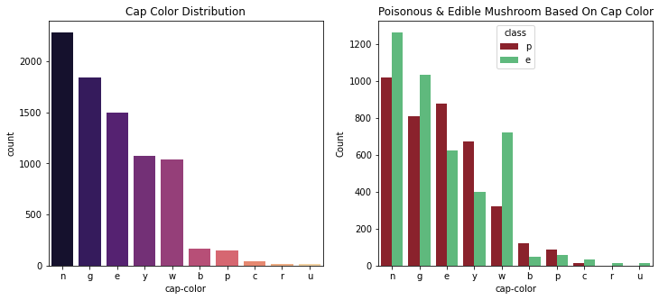

```python
fig, axarr = plt.subplots(1, 2, figsize=(12,5))
a = sns.countplot(Fung['cap-color'], ax=axarr[0], order=Fung['cap-color'].value_counts().index, palette="magma").set_title('Cap Color Distribution')
axarr[1].set_title('Poisonous & Edible Mushroom Based On Cap Color')
b = sns.countplot(x="cap-color", data=Fung, hue="class", order=Fung['cap-color'].value_counts().index, palette=('#9b111e','#50c878'), ax=axarr[1]).set_ylabel('Count')
```

## Olor de los hongos

```python
Fung.groupby(['odor'])['class'].value_counts().to_frame()
```

| odor | class | class |
| --- | --- | --- |
| a | e | 400 |
| c | p | 192 |
| f | p | 2160 |
| l | e | 400 |
| m | p | 36 |
| n | e | 3408 |
|  | p | 120 |
| p | p | 256 |
| s | p | 576 |
| y | p | 576 |

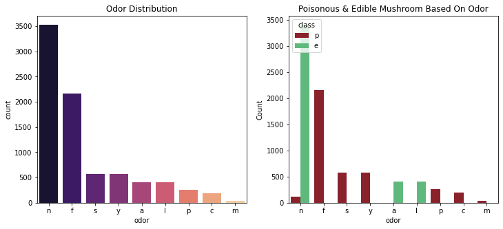

```python
fig, axarr = plt.subplots(1, 2, figsize=(12,5))
a = sns.countplot(Fung['odor'], ax=axarr[0], order=Fung['odor'].value_counts().index, palette="magma").set_title('Odor Distribution')
axarr[1].set_title('Poisonous & Edible Mushroom Based On Odor')
b = sns.countplot(x="odor", data=Fung, hue="class", order=Fung['odor'].value_counts().index, palette=('#9b111e','#50c878'), ax=axarr[1]).set_ylabel('Count')
```

## Tipo de superficie

```python
Fung.groupby(['cap-surface'])['class'].value_counts().to_frame()
```

| cap-surface | class | class |
| --- | --- | --- |
| f | e | 1560 |
|  | p | 760 |
| g | p | 4 |
| s | p | 1412 |
|  | e | 1144 |
| y | p | 1740 |
|  | e | 1504 |

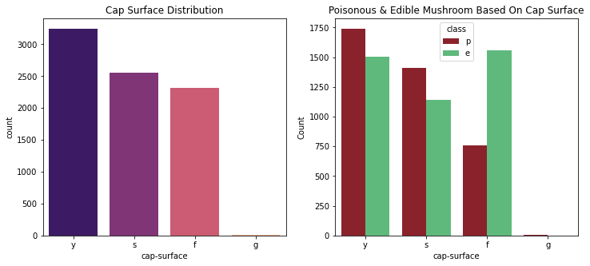

```python
fig, axarr = plt.subplots(1, 2, figsize=(12,5))
a = sns.countplot(Fung['cap-surface'], ax=axarr[0], order=Fung['cap-surface'].value_counts().index, palette="magma").set_title('Cap Surface Distribution')
axarr[1].set_title('Poisonous & Edible Mushroom Based On Cap Surface')
b = sns.countplot(x="cap-surface", data=Fung, hue="class", order=Fung['cap-surface'].value_counts().index, palette=('#9b111e','#50c878'), ax=axarr[1]).set_ylabel('Count')
```

## Mas Información adicional

Si se desea observar mas información del archivo de los hongos se puede visitar el siguiente link en donde se visualizan graficamente los otros 18 atributos que se encuentran en el archivo.

- https://www.kaggle.com/sunaysawant/mushroom-classification-random-forest-100